# Practical Machine Learning Course Project

Smita

27 May 2016

## Background

Using devices such as Jawbone Up, Nike FuelBand, and Fitbit it is now possible to collect a large amount of data about personal activity relatively inexpensively. These type of devices are part of the quantified self movement - a group of enthusiasts who take measurements about themselves regularly to improve their health, to find patterns in their behavior, or because they are tech geeks. One thing that people regularly do is quantify how much of a particular activity they do, but they rarely quantify how well they do it. In this project, your goal will be to use data from accelerometers on the belt, forearm, arm, and dumbell of 6 participants. They were asked to perform barbell lifts correctly and incorrectly in 5 different ways. More information is available from the website here: http://groupware.les.inf.puc-rio.br/har (see the section on the Weight Lifting Exercise Dataset).

## Data

The training data for this project are available here:

https://d396qusza40orc.cloudfront.net/predmachlearn/pml-training.csv

The test data are available here:

https://d396qusza40orc.cloudfront.net/predmachlearn/pml-testing.csv

## Goal

The goal of this project is to predict the manner in which they did the exercise. This is the “classe” variable in the training set. Model on traning data to predict the test data.

## Analysis

We first Install the required packages

```r
library(caret)
library(rattle)
library(rpart)
library(randomForest)
library(MASS)
```

### Step1 : Download the training data and divide it training,testing and validation data.

```r
if (!file.exists("pml-training.csv")) {
trainURL <- "https://d396qusza40orc.cloudfront.net/predmachlearn/pml-training.csv"
download.file(trainURL,destfile="pml-training.csv")
}
dat = read.csv("pml-training.csv")
```

Quick look at the data shows most of the columns are NA and so can be dropped. Also the first 7 columns are just the user details and timestamps which we do not need to predict the manner of exercise.

```r
dat1 <- subset(dat,select=c(8:11,37:49,60:68,84:86,102,113:124,140,151:160))
inTrain <- createDataPartition(dat1$classe,p=0.75,list=FALSE)
validData <- dat1[-inTrain,]
dat1 <- dat1[inTrain,]
inTrain <- createDataPartition(dat1$classe,p=0.75,list=FALSE)
trainData <- dat1[inTrain,]
testData <- dat1[-inTrain,]
```

### Step2 : Build model using traning data and predict the test data. Verify the accuracy.

#### We first try the rpart method since our object is to classify.

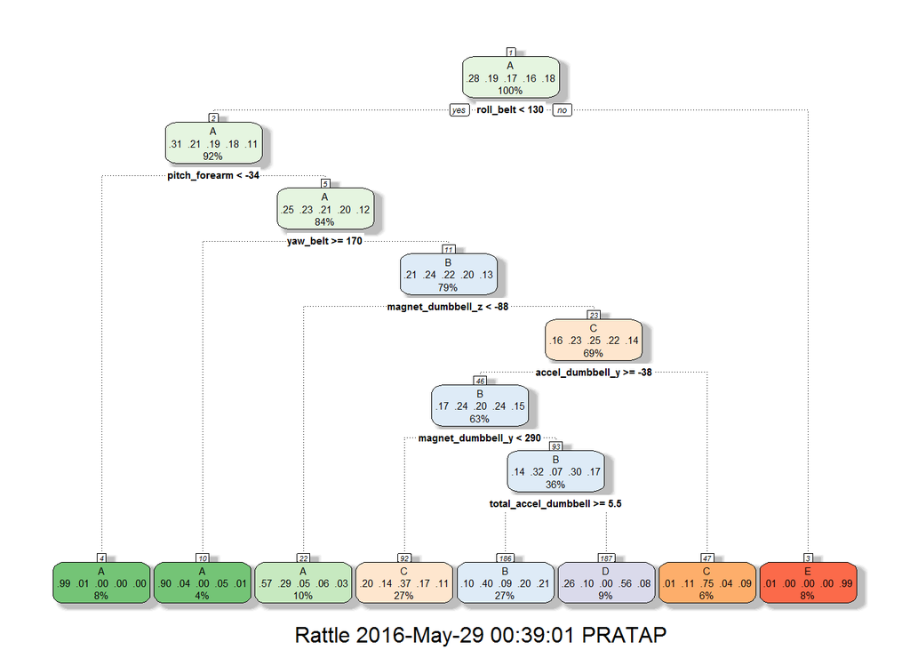

```r
modFit <- train(trainData$classe ~ ., data = trainData, method="rpart")
fancyRpartPlot(modFit$finalModel)
```

```r
print(modFit,digit=3)
```

```
## CART
##
## 11040 samples
##    52 predictor
##     5 classes: 'A', 'B', 'C', 'D', 'E'
##
## No pre-processing
## Resampling: Bootstrapped (25 reps)
## Summary of sample sizes: 11040, 11040, 11040, 11040, 11040, 11040, ...
## Resampling results across tuning parameters:
##
##   cp      Accuracy  Kappa
##   0.0273  0.550     0.4257
##   0.0429  0.468     0.2995
##   0.1156  0.323     0.0599
##
## Accuracy was used to select the optimal model using  the largest value.
## The final value used for the model was cp = 0.0273.
```

```r
#Predict against training and testing data
trainPredict <- predict(modFit,trainData)
testPredict <- predict(modFit,testData)

#check accuracy
confusionMatrix(trainPredict,trainData$classe)$overall[1]
```

```
##  Accuracy
## 0.5638587
```

```r
confusionMatrix(testPredict,testData$classe)$overall[1]
```

```
##  Accuracy
## 0.5693312
```

Very low accuracy, try incorporating pre processing and cross validation

```r
modFit <- train(trainData$classe ~ .,preProcess=c("center", "scale"), trControl=trainControl(method = "cv", number = 4), data = trainData, method="rpart")
print(modFit,digit=3)
```

```
## CART
##
## 11040 samples
##    52 predictor
##     5 classes: 'A', 'B', 'C', 'D', 'E'
##
## Pre-processing: centered (52), scaled (52)
## Resampling: Cross-Validated (4 fold)
## Summary of sample sizes: 8281, 8280, 8279, 8280
## Resampling results across tuning parameters:
##
##   cp      Accuracy  Kappa
##   0.0273  0.558     0.439
##   0.0429  0.440     0.250
##   0.1156  0.324     0.061
##
## Accuracy was used to select the optimal model using  the largest value.
## The final value used for the model was cp = 0.0273.
```

```r
trainPredict <- predict(modFit,trainData)
confusionMatrix(trainPredict,trainData$classe)$overall[1]
```

```
##  Accuracy
## 0.5638587
```

There is no improvement in accuracy, so we try another method

## Repeat Step2 with method LDA

```r
modFit <- train(trainData$classe ~ ., data = trainData, method="lda")
print(modFit,digit=3)
```

```
## Linear Discriminant Analysis
##
## 11040 samples
##    52 predictor
##     5 classes: 'A', 'B', 'C', 'D', 'E'
##
## No pre-processing
## Resampling: Bootstrapped (25 reps)
## Summary of sample sizes: 11040, 11040, 11040, 11040, 11040, 11040, ...
## Resampling results:
##
##   Accuracy  Kappa
##   0.703     0.624
##
##
```

```r
trainPredict <- predict(modFit,trainData)
testPredict <- predict(modFit,testData)

confusionMatrix(trainPredict,trainData$classe)$overall[1]
```

```
##  Accuracy
## 0.7092391
```

```r
confusionMatrix(testPredict,testData$classe)$overall[1]
```

```
##  Accuracy
## 0.7077216
```

```r
# Accuracy better than rpart but not satisfactory

modFit <- train(trainData$classe ~ .,preProcess=c("center", "scale"), trControl=trainControl(method = "cv", number = 4), data = trainData, method="lda")
print(modFit,digit=3)
```

```
## Linear Discriminant Analysis
##
## 11040 samples
##    52 predictor
##     5 classes: 'A', 'B', 'C', 'D', 'E'
##
## Pre-processing: centered (52), scaled (52)
## Resampling: Cross-Validated (4 fold)
## Summary of sample sizes: 8281, 8281, 8280, 8278
## Resampling results:
##
##   Accuracy  Kappa
##   0.704     0.626
##
##
```

```r
trainPredict <- predict(modFit,trainData)
confusionMatrix(trainPredict,trainData$classe)$overall[1]
```

```
##  Accuracy
## 0.7092391
```

The accuracy is not satisfactory. We try another method.

## Repeat step 2 with method RF

```r
modFit <- train(trainData$classe ~ ., data = trainData, method="rf",ntree=100,preProcess=c("center", "scale"), trControl=trainControl(method = "cv", number = 4))

print(modFit,digit=3)
```

```
## Random Forest
##
## 11040 samples
##    52 predictor
##     5 classes: 'A', 'B', 'C', 'D', 'E'
##
## Pre-processing: centered (52), scaled (52)
## Resampling: Cross-Validated (4 fold)
## Summary of sample sizes: 8278, 8282, 8279, 8281
## Resampling results across tuning parameters:
##
##   mtry  Accuracy  Kappa
##    2    0.986     0.983
##   27    0.987     0.984
##   52    0.983     0.979
##
## Accuracy was used to select the optimal model using  the largest value.
## The final value used for the model was mtry = 27.
```

```r
trainPredict <- predict(modFit,trainData)
testPredict <- predict(modFit,testData)

confusionMatrix(trainPredict,trainData$classe)$overall[1]
```

```
## Accuracy
##        1
```

```r
accuracy <- confusionMatrix(testPredict,testData$classe)$overall[1]
```

Accuracy of `0.9921153`is satisfactory. So we finalise the Random forest to predict our data.

### Step 3 Calculate out of sample error.

We haven’t used the validation data in building the model so we can use the validation data to find out of sample error

```r
validPredict <- predict(modFit,validData)
accuracy <- confusionMatrix(validPredict,validData$classe)$overall[1]
```

Error rate is (1-accuracy) i.e 1-`0.9908238`= `0.0091762`

### Step 4 : Final step, Predict the 20 test cases

```r
#Download the testing data
testUrl <- "https://d396qusza40orc.cloudfront.net/predmachlearn/pml-testing.csv"
download.file(testUrl,destfile="pml-testing.csv")
testingData <- read.csv("pml-testing.csv")
testingData1 <- subset(testingData,select=c(8:11,37:49,60:68,84:86,102,113:124,140,151:160))
#Use the model to predict the testing data.
finalPredict <- predict(modFit,newdata=testingData1)
print(finalPredict)
```

```
##  [1] B A B A A E D B A A B C B A E E A B B B
## Levels: A B C D E
```